# Lab 6: Math 4753

Lucia Nguyen

2026-10-08

# Tasks

## Task 1

- WD

```r
getwd()
```

```
## [1] "/Users/jeli/Desktop/Math 4753/lab6"
```

## Task 2

- Use layout() to make a plotting region that holds 4 plots, then plot the 4 normal curves

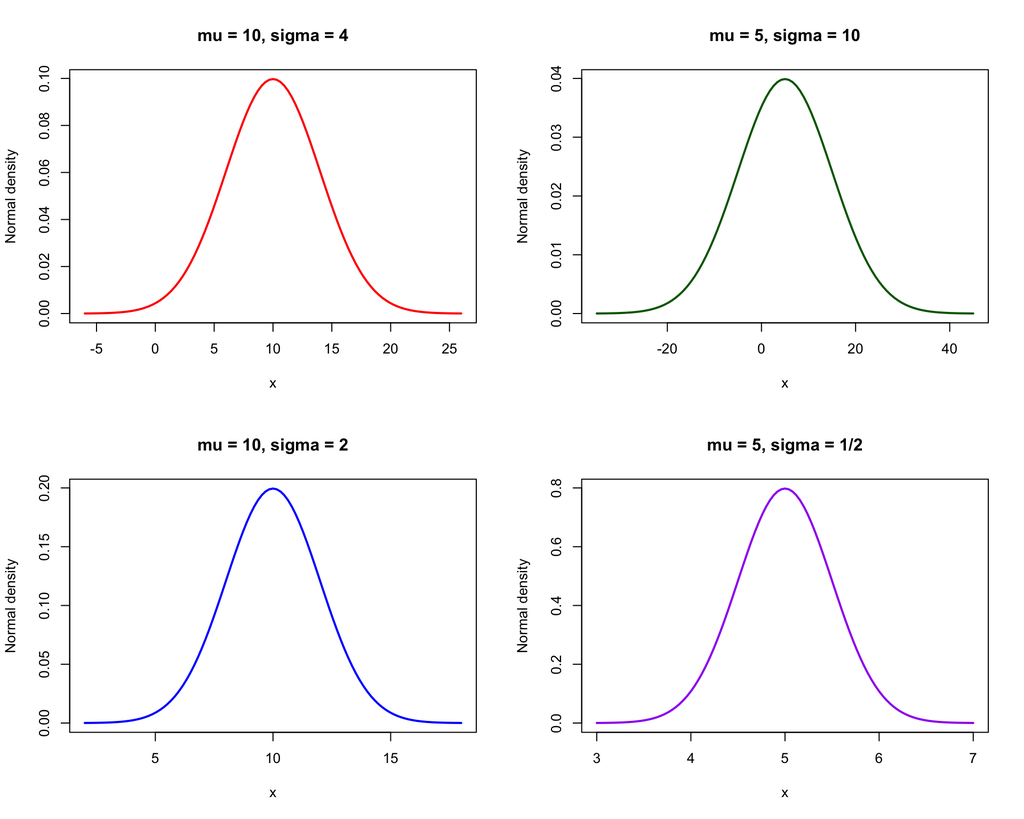

```r
# split the plotting window into a 2 by 2 grid
layout(matrix(1:4, nrow = 2, ncol = 2))

# mu = 10, sigma = 4 (xlim covers mu +/- 4 sigma)
curve(dnorm(x, mean = 10, sd = 4), xlim = c(-6, 26), col = "Red", lwd = 2,
      ylab = "Normal density", main = "mu = 10, sigma = 4")

# mu = 10, sigma = 2
curve(dnorm(x, mean = 10, sd = 2), xlim = c(2, 18), col = "Blue", lwd = 2,
      ylab = "Normal density", main = "mu = 10, sigma = 2")

# mu = 5, sigma = 10 (very spread out so it needs a wide xlim)
curve(dnorm(x, mean = 5, sd = 10), xlim = c(-35, 45), col = "Darkgreen", lwd = 2,
      ylab = "Normal density", main = "mu = 5, sigma = 10")

# mu = 5, sigma = 1/2 (very narrow so it needs a small xlim)
curve(dnorm(x, mean = 5, sd = 0.5), xlim = c(3, 7), col = "Purple", lwd = 2,
      ylab = "Normal density", main = "mu = 5, sigma = 1/2")
```

- $Y \sim N(0, 1), \ P(Y \geq 2)$

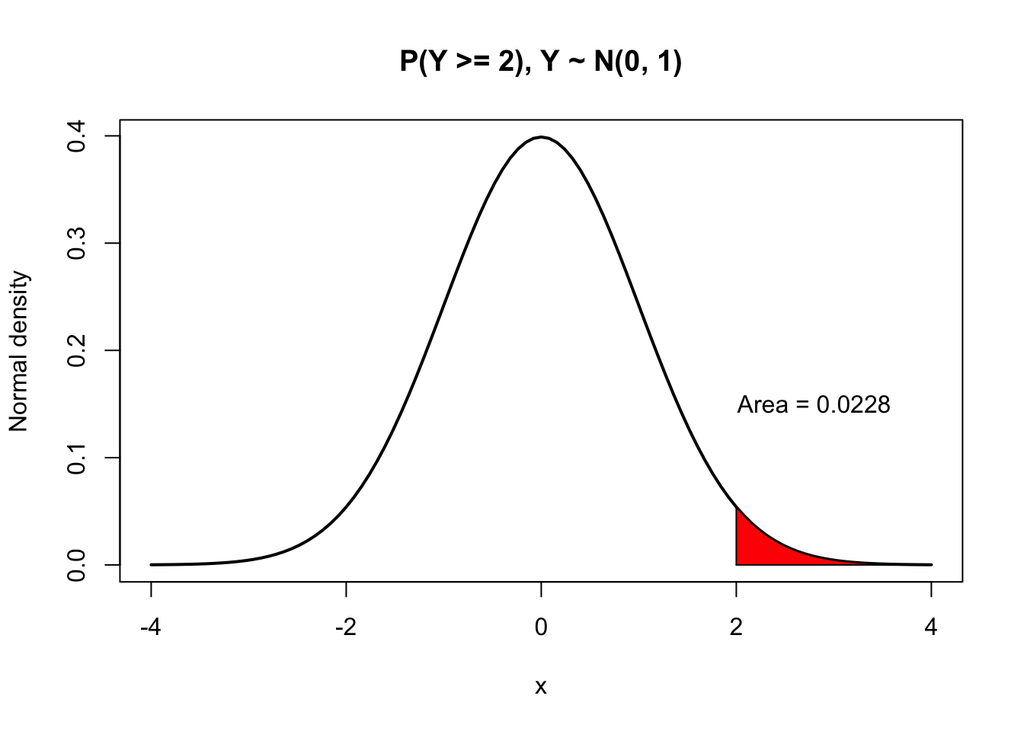

```r
# draw the standard normal curve
curve(dnorm(x, mean = 0, sd = 1), xlim = c(-4, 4), lwd = 2,
      ylab = "Normal density", main = "P(Y >= 2), Y ~ N(0, 1)")

# x values from 2 out to the end of the plot (stands in for infinity)
xcurve = seq(2, 4, length = 1000)

# y values on the curve for those x values
ycurve = dnorm(xcurve, mean = 0, sd = 1)

# shade the area under the curve
polygon(c(2, xcurve, 4), c(0, ycurve, 0), col = "Red")

# area = 1 - P(Y < 2)
prob = 1 - pnorm(2, mean = 0, sd = 1)
prob = round(prob, 4)

# put the area on the graph
text(2.8, 0.15, paste("Area = ", prob, sep = ""))
```

```r
prob
```

```
## [1] 0.0228
```

- $Y \sim N(\mu = 4, \sigma = 2), \ P(1 \leq Y < 5)$

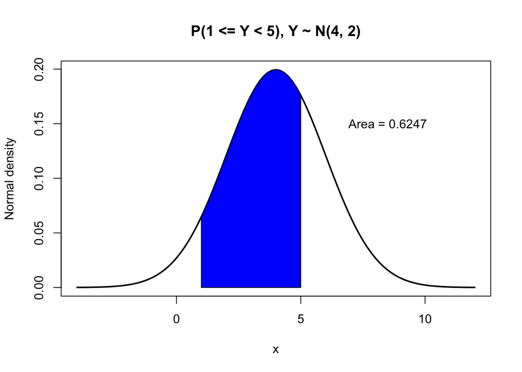

```r
# draw the normal curve
curve(dnorm(x, mean = 4, sd = 2), xlim = c(-4, 12), lwd = 2,
      ylab = "Normal density", main = "P(1 <= Y < 5), Y ~ N(4, 2)")

# x values between 1 and 5
xcurve = seq(1, 5, length = 1000)
ycurve = dnorm(xcurve, mean = 4, sd = 2)

# shade the region
polygon(c(1, xcurve, 5), c(0, ycurve, 0), col = "Blue")

# area = P(Y < 5) - P(Y < 1)
prob = pnorm(5, mean = 4, sd = 2) - pnorm(1, mean = 4, sd = 2)
prob = round(prob, 4)

text(8.5, 0.15, paste("Area = ", prob, sep = ""))
```

```r
prob
```

```
## [1] 0.6247
```

- $Y \sim N(\mu = 10, \sigma = 4), \ P(Y < 10)$

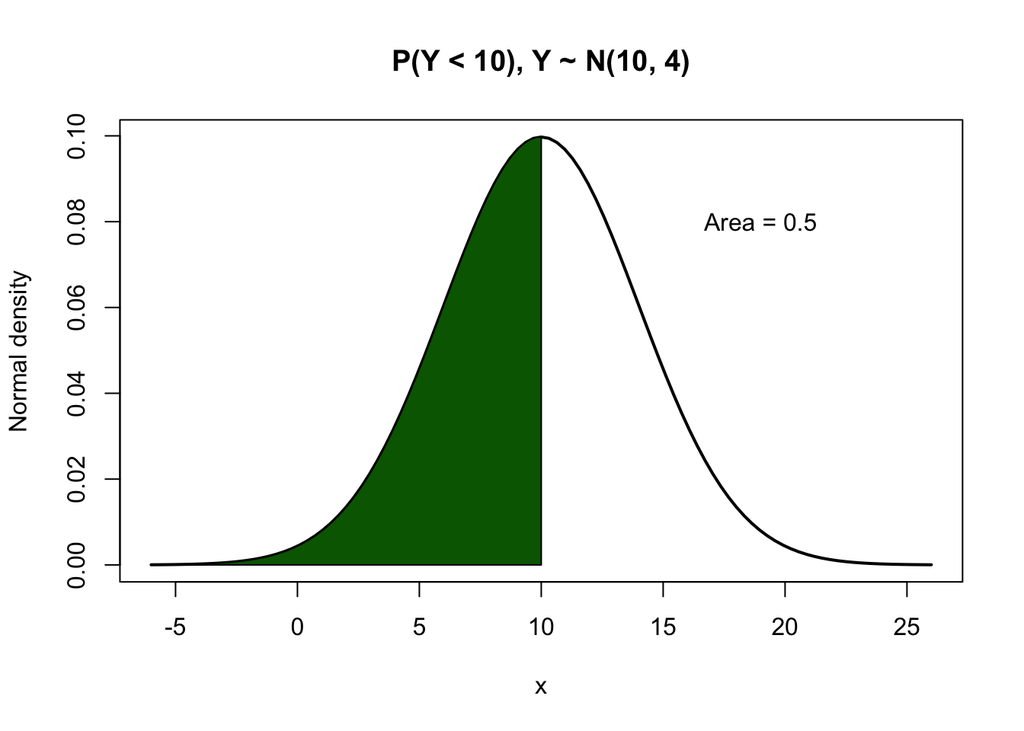

```r
# draw the normal curve
curve(dnorm(x, mean = 10, sd = 4), xlim = c(-6, 26), lwd = 2,
      ylab = "Normal density", main = "P(Y < 10), Y ~ N(10, 4)")

# x values from the left end of the plot up to 10
xcurve = seq(-6, 10, length = 1000)
ycurve = dnorm(xcurve, mean = 10, sd = 4)

# shade the region
polygon(c(-6, xcurve, 10), c(0, ycurve, 0), col = "Darkgreen")

# area = P(Y < 10), should be 0.5 since 10 is the mean
prob = pnorm(10, mean = 10, sd = 4)
prob = round(prob, 4)

text(19, 0.08, paste("Area = ", prob, sep = ""))
```

```r
prob
```

```
## [1] 0.5
```

- $Y \sim N(\mu = -2, \sigma = \frac{1}{2}), \ P(-3 < Y \leq -2)$

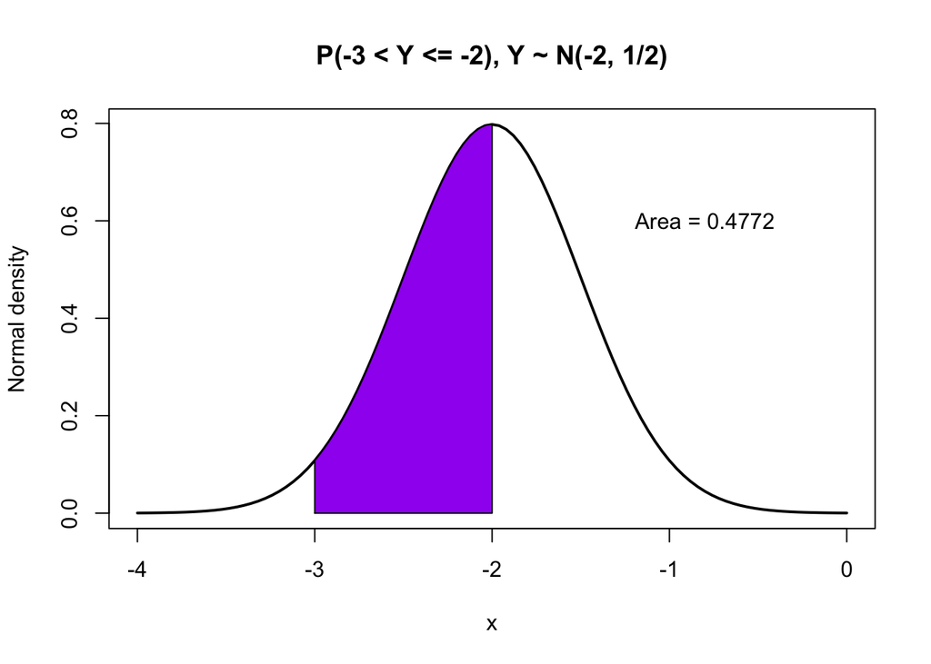

```r
# draw the normal curve
curve(dnorm(x, mean = -2, sd = 0.5), xlim = c(-4, 0), lwd = 2,
      ylab = "Normal density", main = "P(-3 < Y <= -2), Y ~ N(-2, 1/2)")

# x values between -3 and -2
xcurve = seq(-3, -2, length = 1000)
ycurve = dnorm(xcurve, mean = -2, sd = 0.5)

# shade the region
polygon(c(-3, xcurve, -2), c(0, ycurve, 0), col = "Purple")

# area = P(Y <= -2) - P(Y <= -3)
prob = pnorm(-2, mean = -2, sd = 0.5) - pnorm(-3, mean = -2, sd = 0.5)
prob = round(prob, 4)

text(-0.8, 0.6, paste("Area = ", prob, sep = ""))
```

```r
prob
```

```
## [1] 0.4772
```

## Task 3

- Overlay the three gamma curves on one plot (no layout)

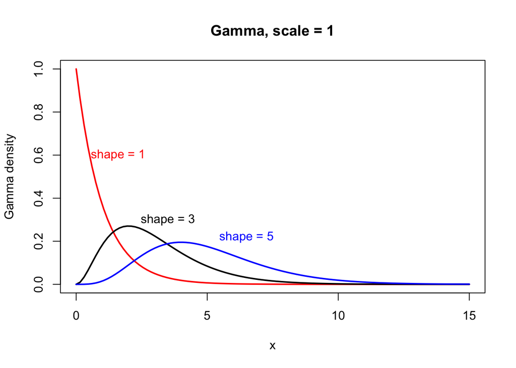

```r
# shape = 1, scale = 1
curve(dgamma(x, shape = 1, scale = 1), xlim = c(0, 15), ylim = c(0, 1),
      col = "Red", lwd = 2, ylab = "Gamma density", main = "Gamma, scale = 1")

# shape = 3, scale = 1 (add = TRUE puts it on the same plot)
curve(dgamma(x, shape = 3, scale = 1), xlim = c(0, 15), ylim = c(0, 1),
      col = "Black", lwd = 2, add = TRUE)

# shape = 5, scale = 1
curve(dgamma(x, shape = 5, scale = 1), xlim = c(0, 15), ylim = c(0, 1),
      col = "Blue", lwd = 2, add = TRUE)

# label each curve
text(1.6, 0.6, "shape = 1", col = "Red")
text(3.5, 0.3, "shape = 3", col = "Black")
text(6.5, 0.22, "shape = 5", col = "Blue")
```

- $Y \sim Gamma(shape = 3, scale = 2), \ P(2 < Y < 5)$

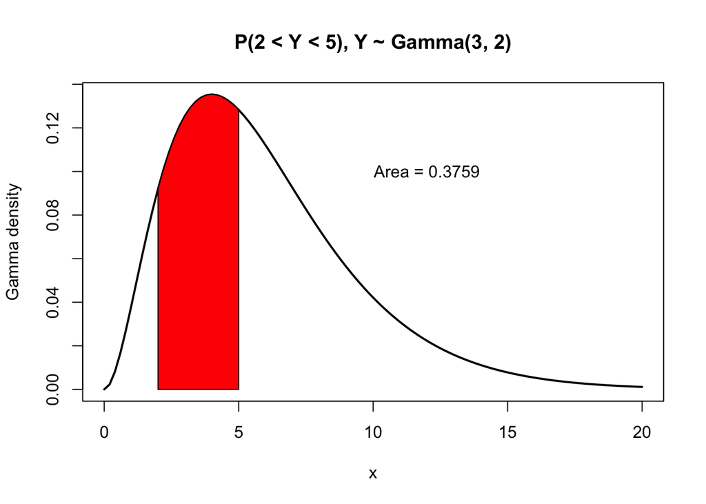

```r
# draw the gamma curve
curve(dgamma(x, shape = 3, scale = 2), xlim = c(0, 20), lwd = 2,
      ylab = "Gamma density", main = "P(2 < Y < 5), Y ~ Gamma(3, 2)")

# x and y values for the region
xcurve = seq(2, 5, length = 1000)
ycurve = dgamma(xcurve, shape = 3, scale = 2)

# shade the region
polygon(c(2, xcurve, 5), c(0, ycurve, 0), col = "Red")

# area = P(Y < 5) - P(Y < 2)
prob = pgamma(5, shape = 3, scale = 2) - pgamma(2, shape = 3, scale = 2)
prob = round(prob, 4)

text(12, 0.1, paste("Area = ", prob, sep = ""))
```

```r
prob
```

```
## [1] 0.3759
```

- $Y \sim Gamma(shape = 6, scale = 3), \ P(1 \leq Y \leq 4)$

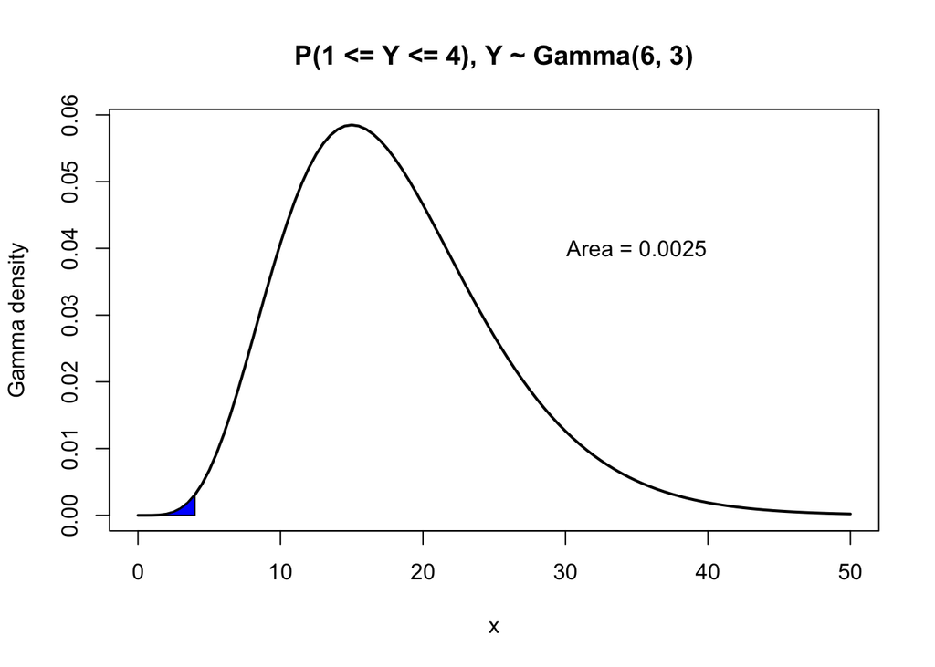

```r
# draw the gamma curve
curve(dgamma(x, shape = 6, scale = 3), xlim = c(0, 50), lwd = 2,
      ylab = "Gamma density", main = "P(1 <= Y <= 4), Y ~ Gamma(6, 3)")

# x and y values for the region
xcurve = seq(1, 4, length = 1000)
ycurve = dgamma(xcurve, shape = 6, scale = 3)

# shade the region (it is very small because 1 to 4 is way in the left tail)
polygon(c(1, xcurve, 4), c(0, ycurve, 0), col = "Blue")

# area = P(Y <= 4) - P(Y <= 1)
prob = pgamma(4, shape = 6, scale = 3) - pgamma(1, shape = 6, scale = 3)
prob = round(prob, 4)

text(35, 0.04, paste("Area = ", prob, sep = ""))
```

```r
prob
```

```
## [1] 0.0025
```

- $Y \sim Gamma(shape = 2, scale = 4), \ P(3 \leq Y < 6)$

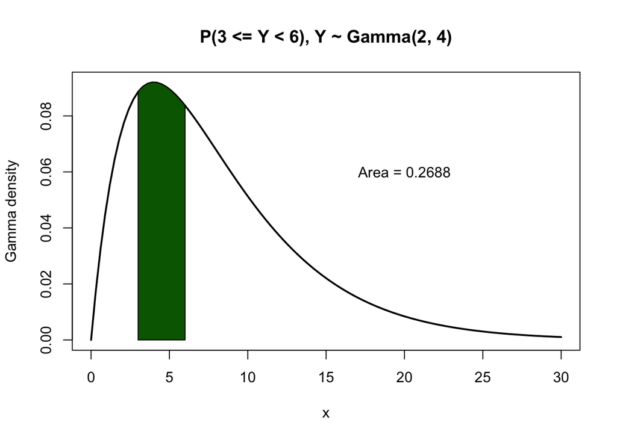

```r
# draw the gamma curve
curve(dgamma(x, shape = 2, scale = 4), xlim = c(0, 30), lwd = 2,
      ylab = "Gamma density", main = "P(3 <= Y < 6), Y ~ Gamma(2, 4)")

# x and y values for the region
xcurve = seq(3, 6, length = 1000)
ycurve = dgamma(xcurve, shape = 2, scale = 4)

# shade the region
polygon(c(3, xcurve, 6), c(0, ycurve, 0), col = "Darkgreen")

# area = P(Y < 6) - P(Y < 3)
prob = pgamma(6, shape = 2, scale = 4) - pgamma(3, shape = 2, scale = 4)
prob = round(prob, 4)

text(20, 0.06, paste("Area = ", prob, sep = ""))
```

```r
prob
```

```
## [1] 0.2688
```

## Task 4

- Use layout() to make 4 squares and plot the 4 chi square curves

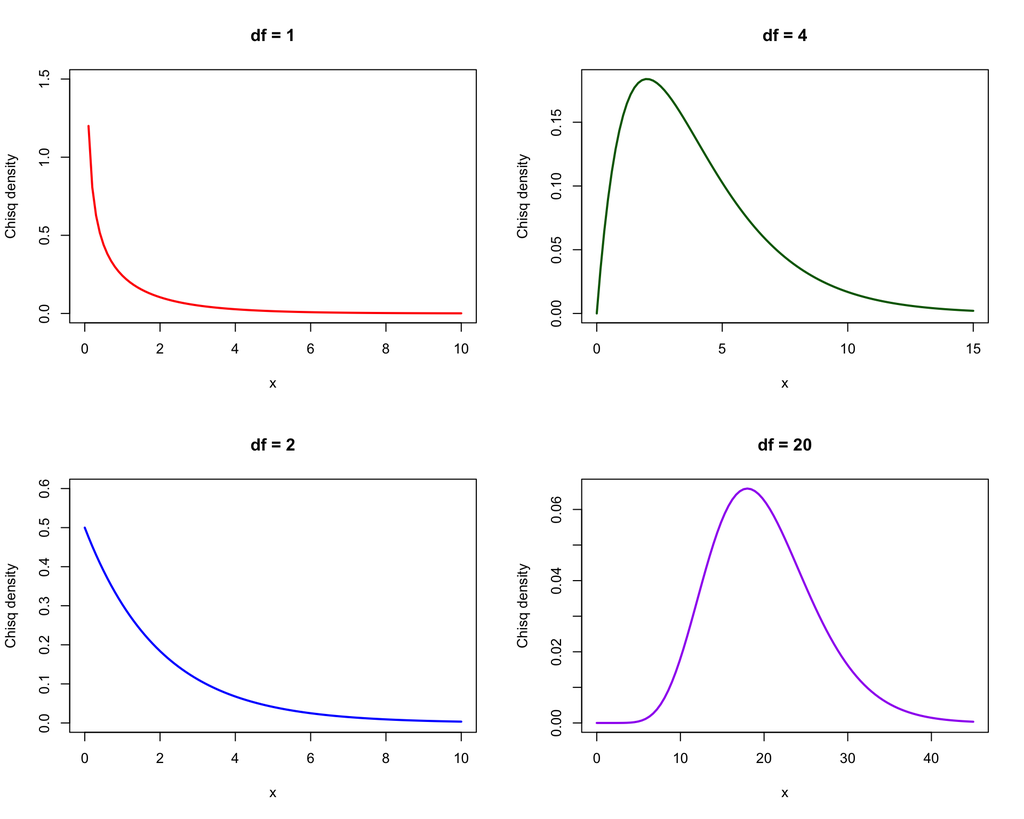

```r
# 2 by 2 plotting grid
layout(matrix(1:4, nrow = 2, ncol = 2))

# df = 1 (shoots up to infinity at 0 so ylim is capped)
curve(dchisq(x, df = 1), xlim = c(0, 10), ylim = c(0, 1.5), col = "Red", lwd = 2,
      ylab = "Chisq density", main = "df = 1")

# df = 2 (this is the same as an exponential with mean 2)
curve(dchisq(x, df = 2), xlim = c(0, 10), ylim = c(0, 0.6), col = "Blue", lwd = 2,
      ylab = "Chisq density", main = "df = 2")

# df = 4
curve(dchisq(x, df = 4), xlim = c(0, 15), col = "Darkgreen", lwd = 2,
      ylab = "Chisq density", main = "df = 4")

# df = 20 (looks more normal as df gets bigger)
curve(dchisq(x, df = 20), xlim = c(0, 45), col = "Purple", lwd = 2,
      ylab = "Chisq density", main = "df = 20")
```

- $Y \sim chisq(df = 2), \ P(2 \leq Y \leq 4)$

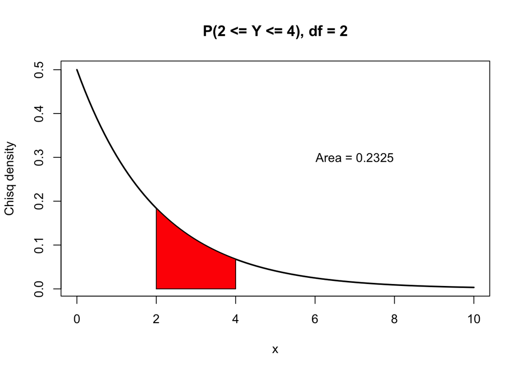

```r
# draw the chi square curve
curve(dchisq(x, df = 2), xlim = c(0, 10), lwd = 2,
      ylab = "Chisq density", main = "P(2 <= Y <= 4), df = 2")

# x and y values for the region
xcurve = seq(2, 4, length = 1000)
ycurve = dchisq(xcurve, df = 2)

# shade the region
polygon(c(2, xcurve, 4), c(0, ycurve, 0), col = "Red")

# area = P(Y <= 4) - P(Y <= 2)
prob = pchisq(4, df = 2) - pchisq(2, df = 2)
prob = round(prob, 4)

text(7, 0.3, paste("Area = ", prob, sep = ""))
```

```r
prob
```

```
## [1] 0.2325
```

- $Y \sim chisq(df = 3), \ P(3 \leq Y \leq 5)$

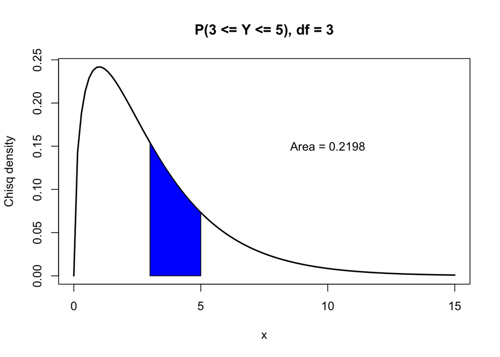

```r
# draw the chi square curve
curve(dchisq(x, df = 3), xlim = c(0, 15), lwd = 2,
      ylab = "Chisq density", main = "P(3 <= Y <= 5), df = 3")

# x and y values for the region
xcurve = seq(3, 5, length = 1000)
ycurve = dchisq(xcurve, df = 3)

# shade the region
polygon(c(3, xcurve, 5), c(0, ycurve, 0), col = "Blue")

# area = P(Y <= 5) - P(Y <= 3)
prob = pchisq(5, df = 3) - pchisq(3, df = 3)
prob = round(prob, 4)

text(10, 0.15, paste("Area = ", prob, sep = ""))
```

```r
prob
```

```
## [1] 0.2198
```

- $Y \sim chisq(df = 20), \ P(10 < Y \leq 21)$

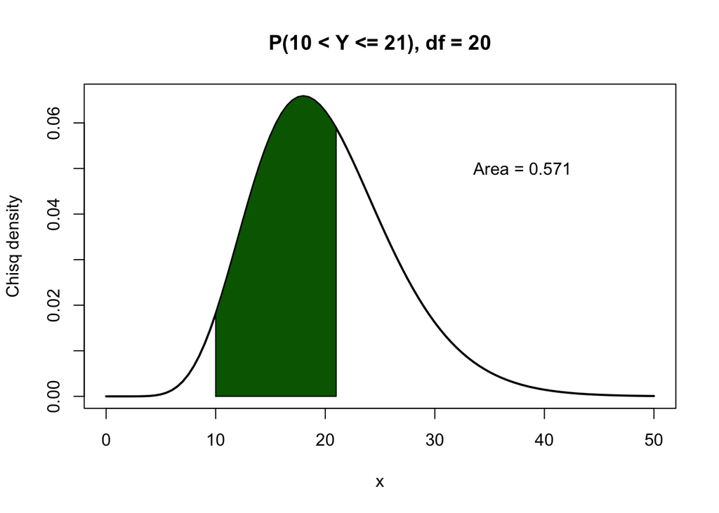

```r
# draw the chi square curve
curve(dchisq(x, df = 20), xlim = c(0, 50), lwd = 2,
      ylab = "Chisq density", main = "P(10 < Y <= 21), df = 20")

# x and y values for the region
xcurve = seq(10, 21, length = 1000)
ycurve = dchisq(xcurve, df = 20)

# shade the region
polygon(c(10, xcurve, 21), c(0, ycurve, 0), col = "Darkgreen")

# area = P(Y <= 21) - P(Y <= 10)
prob = pchisq(21, df = 20) - pchisq(10, df = 20)
prob = round(prob, 4)

text(38, 0.05, paste("Area = ", prob, sep = ""))
```

```r
prob
```

```
## [1] 0.571
```

## Task 5

- Four Weibull curves with different shape and scale (using layout())

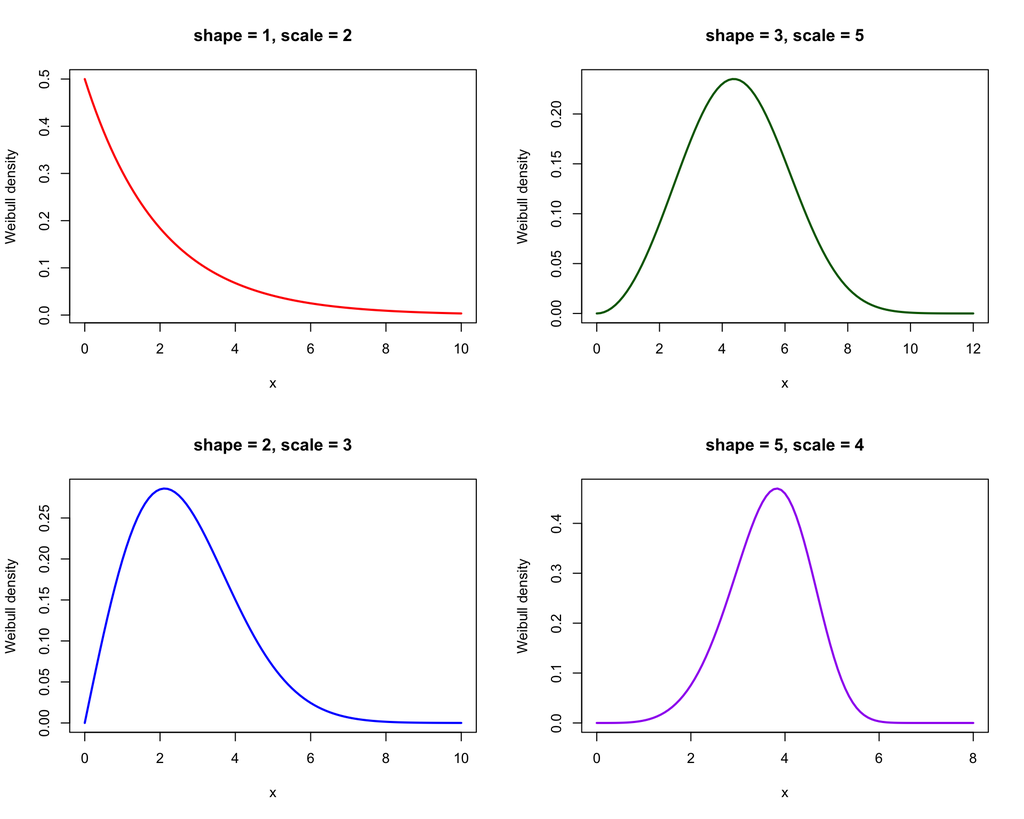

```r
# 2 by 2 plotting grid
layout(matrix(1:4, nrow = 2, ncol = 2))

# shape = 1 makes it the same as an exponential
curve(dweibull(x, shape = 1, scale = 2), xlim = c(0, 10), col = "Red", lwd = 2,
      ylab = "Weibull density", main = "shape = 1, scale = 2")

# shape = 2, scale = 3
curve(dweibull(x, shape = 2, scale = 3), xlim = c(0, 10), col = "Blue", lwd = 2,
      ylab = "Weibull density", main = "shape = 2, scale = 3")

# shape = 3, scale = 5
curve(dweibull(x, shape = 3, scale = 5), xlim = c(0, 12), col = "Darkgreen", lwd = 2,
      ylab = "Weibull density", main = "shape = 3, scale = 5")

# shape = 5, scale = 4 (bigger shape makes it more peaked)
curve(dweibull(x, shape = 5, scale = 4), xlim = c(0, 8), col = "Purple", lwd = 2,
      ylab = "Weibull density", main = "shape = 5, scale = 4")
```

- $Y \sim Weibull(shape = 2, scale = 3), \ P(1 \leq Y \leq 4)$

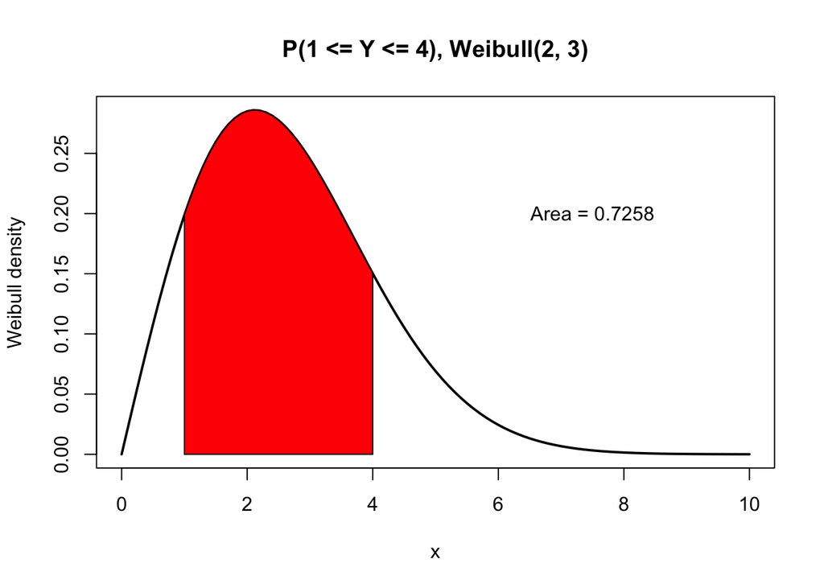

```r
# draw the weibull curve
curve(dweibull(x, shape = 2, scale = 3), xlim = c(0, 10), lwd = 2,
      ylab = "Weibull density", main = "P(1 <= Y <= 4), Weibull(2, 3)")

# x and y values for the region
xcurve = seq(1, 4, length = 1000)
ycurve = dweibull(xcurve, shape = 2, scale = 3)

# shade the region
polygon(c(1, xcurve, 4), c(0, ycurve, 0), col = "Red")

# area = P(Y <= 4) - P(Y <= 1)
prob = pweibull(4, shape = 2, scale = 3) - pweibull(1, shape = 2, scale = 3)
prob = round(prob, 4)

text(7.5, 0.2, paste("Area = ", prob, sep = ""))
```

```r
prob
```

```
## [1] 0.7258
```

- $Y \sim Weibull(shape = 3, scale = 5), \ P(Y \leq 6)$

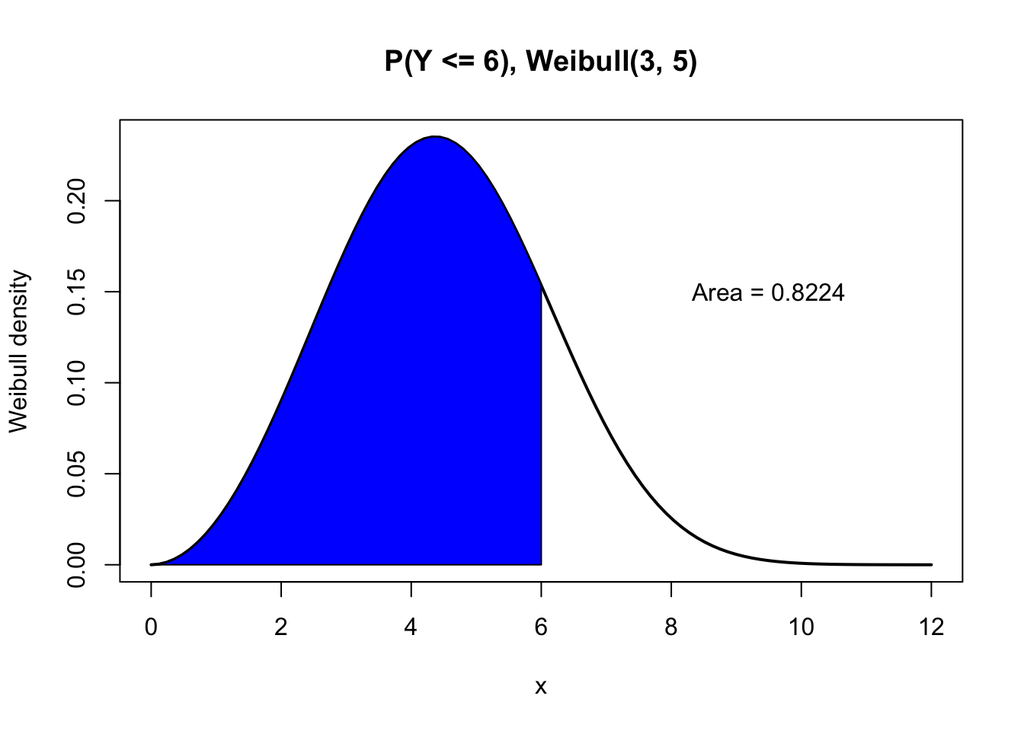

```r
# draw the weibull curve
curve(dweibull(x, shape = 3, scale = 5), xlim = c(0, 12), lwd = 2,
      ylab = "Weibull density", main = "P(Y <= 6), Weibull(3, 5)")

# x and y values from 0 to 6
xcurve = seq(0, 6, length = 1000)
ycurve = dweibull(xcurve, shape = 3, scale = 5)

# shade the region
polygon(c(0, xcurve, 6), c(0, ycurve, 0), col = "Blue")

# area = P(Y <= 6)
prob = pweibull(6, shape = 3, scale = 5)
prob = round(prob, 4)

text(9.5, 0.15, paste("Area = ", prob, sep = ""))
```

```r
prob
```

```
## [1] 0.8224
```

- $Y \sim Weibull(shape = 5, scale = 4), \ P(3 < Y < 5)$

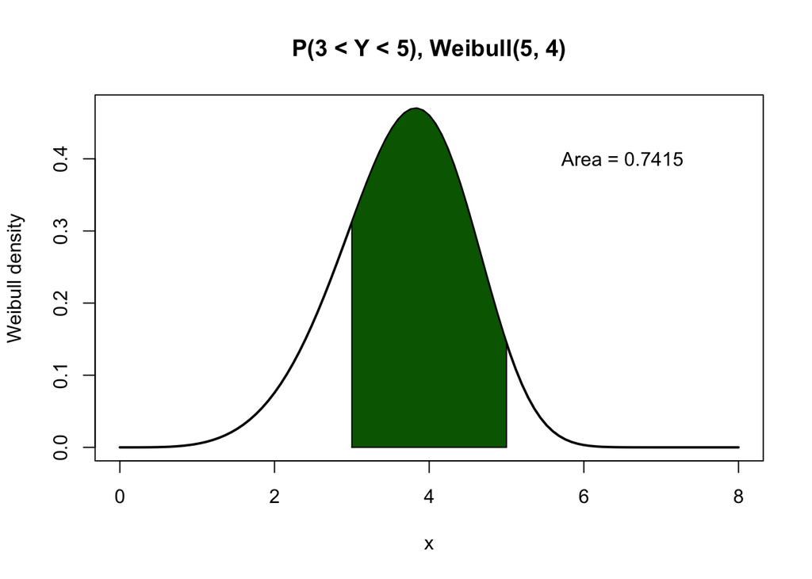

```r
# draw the weibull curve
curve(dweibull(x, shape = 5, scale = 4), xlim = c(0, 8), lwd = 2,
      ylab = "Weibull density", main = "P(3 < Y < 5), Weibull(5, 4)")

# x and y values for the region
xcurve = seq(3, 5, length = 1000)
ycurve = dweibull(xcurve, shape = 5, scale = 4)

# shade the region
polygon(c(3, xcurve, 5), c(0, ycurve, 0), col = "Darkgreen")

# area = P(Y < 5) - P(Y < 3)
prob = pweibull(5, shape = 5, scale = 4) - pweibull(3, shape = 5, scale = 4)
prob = round(prob, 4)

text(6.5, 0.4, paste("Area = ", prob, sep = ""))
```

```r
prob
```

```
## [1] 0.7415
```

## Task 6

- From ?dbeta: the beta has two shape parameters, shape1 = $\alpha$ and shape2 = $\beta$, both > 0. The density is $f(y) = \frac{\Gamma(\alpha + \beta)}{\Gamma(\alpha)\Gamma(\beta)} y^{\alpha - 1}(1 - y)^{\beta - 1}$ for $0 \leq y \leq 1$, and the mean is $\frac{\alpha}{\alpha + \beta}$. When $\alpha = \beta$ it is symmetric about 0.5, a bigger $\alpha$ pushes it to the right and a bigger $\beta$ pushes it to the left.

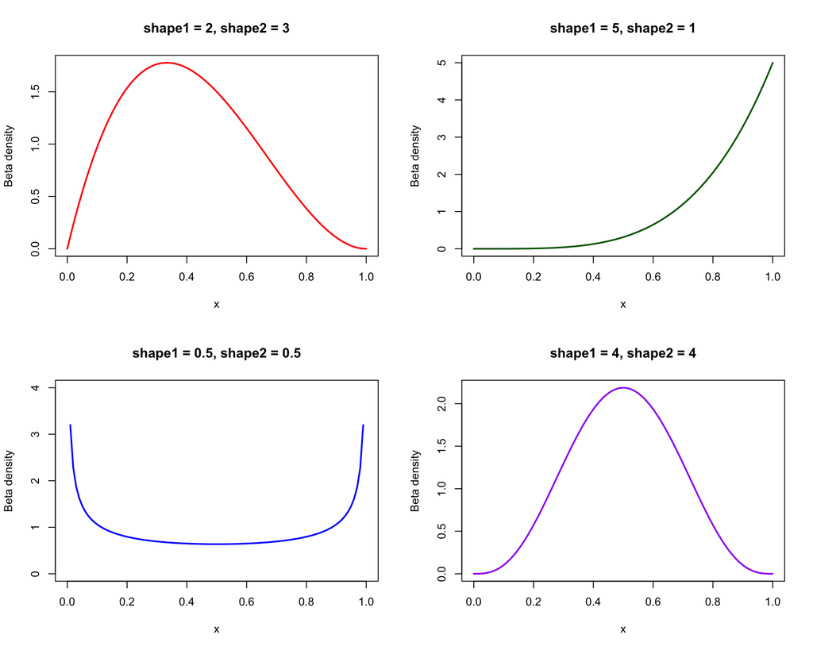

```r
# 2 by 2 plotting grid
layout(matrix(1:4, nrow = 2, ncol = 2))

# shape1 = 2, shape2 = 3 (skewed right, mean = 0.4)
curve(dbeta(x, shape1 = 2, shape2 = 3), xlim = c(0, 1), col = "Red", lwd = 2,
      ylab = "Beta density", main = "shape1 = 2, shape2 = 3")

# shape1 = 0.5, shape2 = 0.5 (U shape, goes to infinity at 0 and 1)
curve(dbeta(x, shape1 = 0.5, shape2 = 0.5), xlim = c(0, 1), ylim = c(0, 4),
      col = "Blue", lwd = 2, ylab = "Beta density", main = "shape1 = 0.5, shape2 = 0.5")

# shape1 = 5, shape2 = 1 (piles up near 1)
curve(dbeta(x, shape1 = 5, shape2 = 1), xlim = c(0, 1), col = "Darkgreen", lwd = 2,
      ylab = "Beta density", main = "shape1 = 5, shape2 = 1")

# shape1 = 4, shape2 = 4 (symmetric bell around 0.5)
curve(dbeta(x, shape1 = 4, shape2 = 4), xlim = c(0, 1), col = "Purple", lwd = 2,
      ylab = "Beta density", main = "shape1 = 4, shape2 = 4")
```

- $Y \sim Beta(2, 3), \ P(0.2 \leq Y \leq 0.6)$

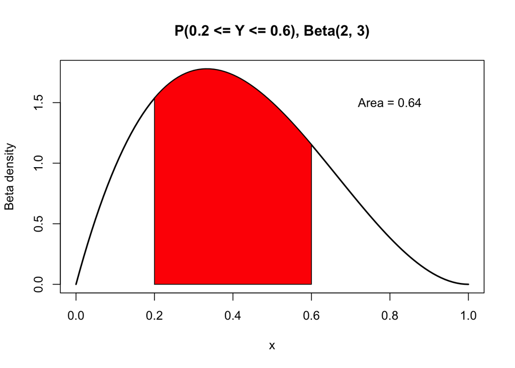

```r
# draw the beta curve
curve(dbeta(x, shape1 = 2, shape2 = 3), xlim = c(0, 1), lwd = 2,
      ylab = "Beta density", main = "P(0.2 <= Y <= 0.6), Beta(2, 3)")

# x and y values for the region
xcurve = seq(0.2, 0.6, length = 1000)
ycurve = dbeta(xcurve, shape1 = 2, shape2 = 3)

# shade the region
polygon(c(0.2, xcurve, 0.6), c(0, ycurve, 0), col = "Red")

# area = P(Y <= 0.6) - P(Y <= 0.2)
prob = pbeta(0.6, shape1 = 2, shape2 = 3) - pbeta(0.2, shape1 = 2, shape2 = 3)
prob = round(prob, 4)

text(0.8, 1.5, paste("Area = ", prob, sep = ""))
```

```r
prob
```

```
## [1] 0.64
```

- $Y \sim Beta(4, 4), \ P(0.3 < Y < 0.5)$

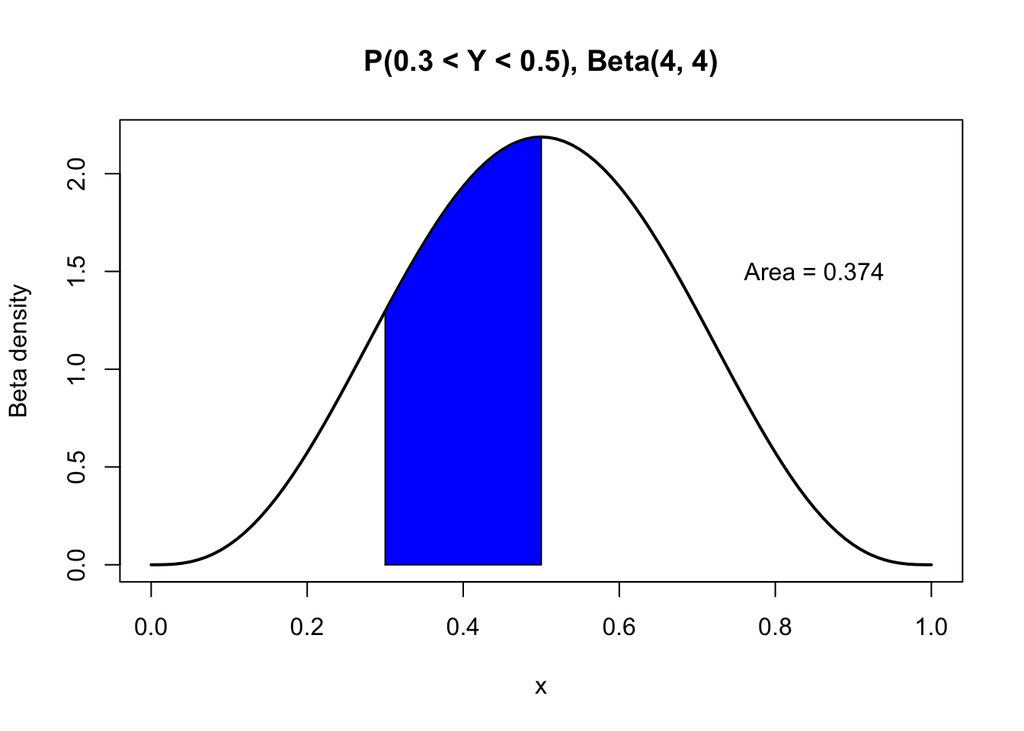

```r
# draw the beta curve
curve(dbeta(x, shape1 = 4, shape2 = 4), xlim = c(0, 1), lwd = 2,
      ylab = "Beta density", main = "P(0.3 < Y < 0.5), Beta(4, 4)")

# x and y values for the region
xcurve = seq(0.3, 0.5, length = 1000)
ycurve = dbeta(xcurve, shape1 = 4, shape2 = 4)

# shade the region
polygon(c(0.3, xcurve, 0.5), c(0, ycurve, 0), col = "Blue")

# area = P(Y < 0.5) - P(Y < 0.3)
prob = pbeta(0.5, shape1 = 4, shape2 = 4) - pbeta(0.3, shape1 = 4, shape2 = 4)
prob = round(prob, 4)

text(0.85, 1.5, paste("Area = ", prob, sep = ""))
```

```r
prob
```

```
## [1] 0.374
```

- $Y \sim Beta(5, 1), \ P(Y > 0.8)$

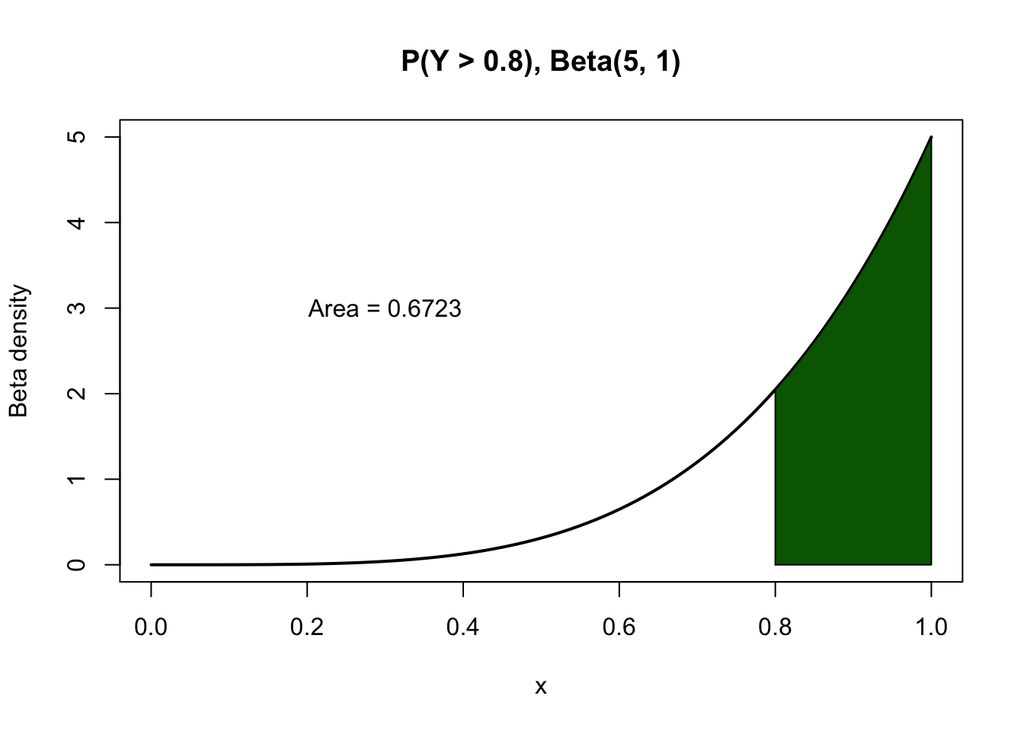

```r
# draw the beta curve
curve(dbeta(x, shape1 = 5, shape2 = 1), xlim = c(0, 1), lwd = 2,
      ylab = "Beta density", main = "P(Y > 0.8), Beta(5, 1)")

# x and y values from 0.8 to 1
xcurve = seq(0.8, 1, length = 1000)
ycurve = dbeta(xcurve, shape1 = 5, shape2 = 1)

# shade the region
polygon(c(0.8, xcurve, 1), c(0, ycurve, 0), col = "Darkgreen")

# area = 1 - P(Y <= 0.8)
prob = 1 - pbeta(0.8, shape1 = 5, shape2 = 1)
prob = round(prob, 4)

text(0.3, 3, paste("Area = ", prob, sep = ""))
```

```r
prob
```

```
## [1] 0.6723
```

## Task 7

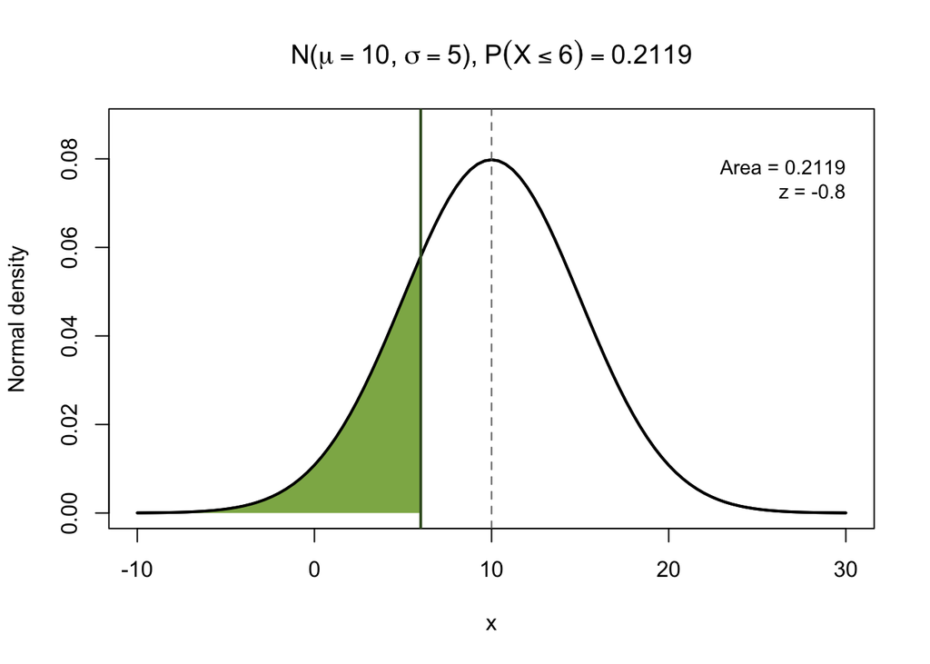

```r
# call myncurve from my package
MATH4753LucNguyenF26::myncurve(mu = 10, sigma = 5, a = 6)
```

- Same thing but pretending mu and sigma came from a sample of 25, so it also gives a 95% CI for the probability

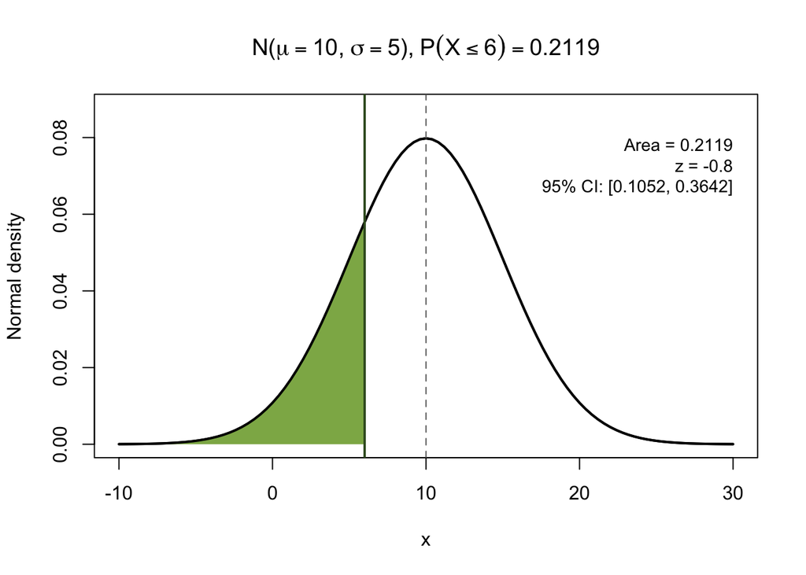

```r
MATH4753LucNguyenF26::myncurve(mu = 10, sigma = 5, a = 6, n = 25)
```

## Task 8

- Use the gamma density to make exponential densities. An exponential with rate $\lambda$ is a gamma with shape = 1 and scale = $\frac{1}{\lambda}$

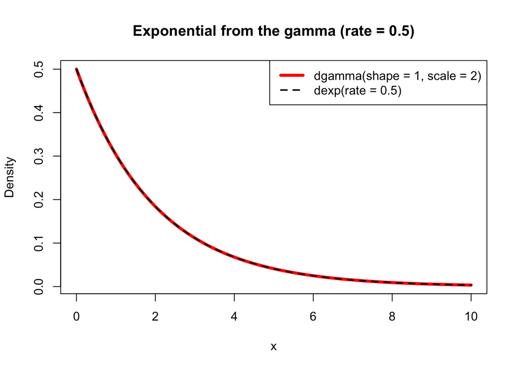

```r
# exponential with rate = 0.5 made from the gamma
curve(dgamma(x, shape = 1, scale = 1 / 0.5), xlim = c(0, 10), col = "Red", lwd = 4,
      ylab = "Density", main = "Exponential from the gamma (rate = 0.5)")

# built in dexp() on top as a dashed line to compare
curve(dexp(x, rate = 0.5), xlim = c(0, 10), col = "Black", lwd = 2, lty = 2, add = TRUE)

legend("topright", legend = c("dgamma(shape = 1, scale = 2)", "dexp(rate = 0.5)"),
       col = c("Red", "Black"), lwd = c(4, 2), lty = c(1, 2))
```

```r
# check numerically that they match at a bunch of x values
x = seq(0, 10, by = 0.5)
all.equal(dgamma(x, shape = 1, scale = 1 / 0.5), dexp(x, rate = 0.5))
```

```
## [1] TRUE
```